Basic Syntax

Lecture 2

[figure not shown]

Review: All code is written in a script

[figure not shown]

Editor vs Console

[figure not shown]

Run Code

[figure not shown]

Review

- #comment

- Explain what’s going on in your code

- I encourage you to comment your

code for the in-class exercises

Today’s Topics:

● Statistical inference

● Variables

● Math operations

● Vectors

Why do we need statistical

inference in science?

[figure not shown]

Statistical Inference

- Can’t study the whole population

- How do we prove something?

- Example: does drug X increase amount of sleep

students get?

[figure not shown]

Can’t study the whole population

Obtain a representative

sample of your population

Statistical Inference

- Test drug X in a sample of students

- How can we be certain difference in amount of sleep is

related to the drug and not random chance?

- Many models/statistical tests attempt to show certain

relationships exist

- R makes it easier to analyze data for relationships and

display results

[figure not shown]

Statistical Inference

- Test drug X in a sample of students

- How can we be certain difference in amount of sleep is

related to the drug and not random chance?

- Many models/statistical tests attempt to show certain

relationships exist

- R makes it easier to analyze data for relationships and

display results

Our ultimate goal

in this course

R dataset: sleep

- Two groups, 10 students each:

- Control: no drug

- Experimental: given sleeping drug

- Measured number of hours each student’s sleep

increased or decreased

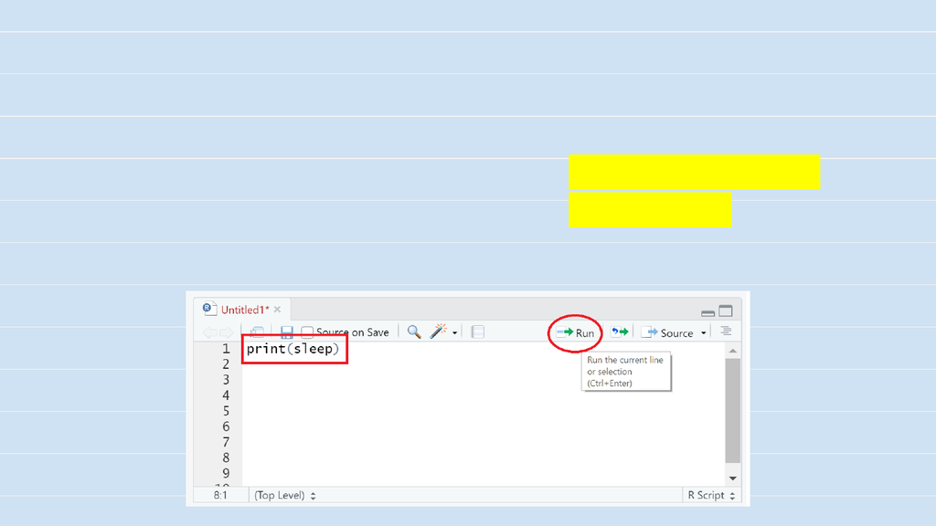

Your Turn: R dataset sleep

- Open up R/RStudio

- Create a new script

- Type in print(sleep) and press “Run”

Note: R is CASE-

SENSITIVE

> print(sleep)

extra group ID

1 0.7 1 1

2 -1.6 1 2

3 -0.2 1 3

4 -1.2 1 4

5 -0.1 1 5

6 3.4 1 6

7 3.7 1 7

8 0.8 1 8

9 0.0 1 9

10 2.0 1 10

11 1.9 2 1

12 0.8 2 2

13 1.1 2 3

14 0.1 2 4

15 -0.1 2 5

16 4.4 2 6

17 5.5 2 7

18 1.6 2 8

19 4.6 2 9

20 3.4 2 10

Output for print(sleep)

extra = increase/decrease

in hours of sleep

group = treatment group

ID = student identifier

Variables

Variables

- Placeholders

- Store information

Example:

- X = 5

- X + 4

- Will be equal to 9

Variables in R

Syntax:

variable_name <- variable_value

variable_name = variable_value

- variable_name must be 1 continuous sequence of

letters/symbols (no spaces)

- Can add underscores in between words

- R is CASE-SENSITIVE

Variables in R: Examples

Syntax:

variable_name <- variable_value

- five <- 5

- print(five)

- data <- dataset_name

- print(data)

Your Turn: R dataset sleep

- Create variable data and store the sleep

dataset in it

- Print data

Syntax Hints

variable_name <- variable_value

print(variable_name)

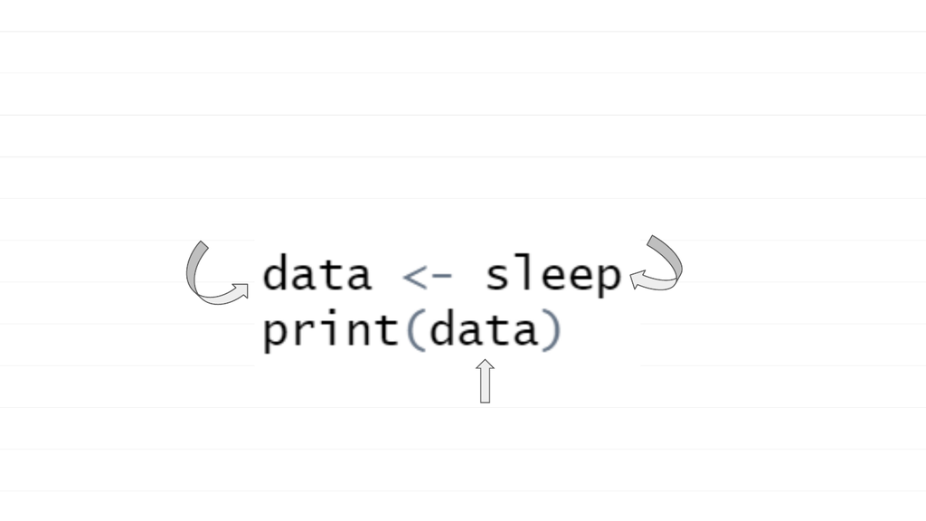

Sleep as a variable called data

Variable

name

Value to be stored

in variable

Can use variable name like

the value stored inside

[figure not shown]

Notes on variable names

Syntax:

variable_name <- variable_value

- variable_name has to be unique

- X <- 1

- X <- 2

- X <- 3

- You have lost the first two assignments to X

- X stores the number 3

[figure not shown]

Notes on variable values

Syntax:

variable_name <- variable_value

- variable_value can be just about anything

- Numbers

- num <- 4

- Characters/words: surround with “quotes”

- word <- “DNA”

- Other variables

- word2 <- word

Your Turn: R dataset sleep

- Create another variable (be creative with its name)

and assign data to that variable

- Print your new variable

Syntax Hints

variable_name <- variable_value

print(variable_name)

Why use variables?

- Save time

- Can change value of variable without changing

how that variable is used

- Creates copy of that value

- Modify data and still have the original sleep

dataset

Order of Operations

Order of Operations

- PEMDAS

- Parentheses ()

- Exponents (^)

- Multiplication (*) & division (/)

- Addition (+) & subtraction (-)

- precedence from left to right

Your Turn: PEMDAS

- What does the following evaluate to?

- 5 + 3 / 2 * 4 - 5

- Feel free to print this to check

Vectors

Vector

- Elements of the same type concatenated together

- Like a list

Syntax:

c(element1, element2, element3, etc)

- Examples:

- c(1, 2, 3, 4, 5)

- c(1)

- c(“Male”, “Female”,”Male”,”Female”)

Your Turn: Vectors

- Make a vector of 3-4 of your classmates’

names

- Store that vector in variable classmates

Syntax Hints

variable_name <- variable_value

c(element1, element2, element3, etc)

Vectors and Variables

- Can assign vectors to variables

- classmates <- c(“student1”, “student2”, “student3”)

- Can print the variable

- print(classmates)

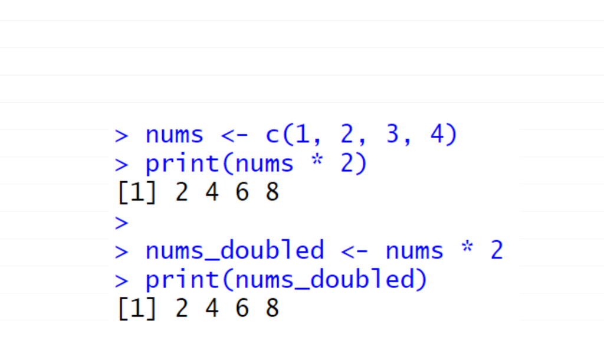

Variables and Order of Operations

- PEMDAS applies to vectors

[figure not shown]

> print(sleep)

extra group ID

1 0.7 1 1

2 -1.6 1 2

3 -0.2 1 3

4 -1.2 1 4

5 -0.1 1 5

6 3.4 1 6

7 3.7 1 7

8 0.8 1 8

9 0.0 1 9

10 2.0 1 10

11 1.9 2 1

12 0.8 2 2

13 1.1 2 3

14 0.1 2 4

15 -0.1 2 5

16 4.4 2 6

17 5.5 2 7

18 1.6 2 8

19 4.6 2 9

20 3.4 2 10

sleep revisited

extra = increase/decrease

in hours of sleep

group = treatment group

ID = student identifier

extra, group, ID are vectors!

A dataset is kind of like a bunch of

vertical vectors next to each other

Vectors and Datasets

Syntax:

dataset_name$column_name

- Gives me a vector for that column

- Examples:

- sleep$extra

- sleep$group

- sleep$ID

Your Turn: All Topics Applied

- extra in the sleep dataset stores sleep difference in hours

- Create variable sleep_difference_minutes that stores a vector

of the sleep differences in minutes

- (Need to multiply each number of hours in extra by 60)

Syntax Hints

variable_name <- variable_value

dataset_name$column_name

Multiplication: *

All Topics Applied

- How to access extra vector from sleep dataset?

- sleep$extra

- How to convert hours to minutes?

- sleep$extra * 60

- How to store that result in a new variable?

- sleep_difference_minutes <- sleep$extra * 60

- Can print sleep_difference_minutes to check

- Not required:

- sleep$sleep_different_minutes <- sleep$extra * 60

- Stores this new vector into the sleep dataset (as a 4th column)

Logistics: Assignment 1 Out Today

- Assignment 1 available on ELMS

- Due in two weeks--some material on HW may be

covered next week in lecture

- Good faith attempt required for full points

- Feel free to collaborate with peers about solutions